# Okun’s law and the US economy

Lovdip Singh

## Question of interest/goal of the study

We want to investigate Okun’s law using data from the US economy. That is, for every 1% decrease in unemployment rate there should be a corresponding 2% increase in GDP.

## Read in and inspect the data:

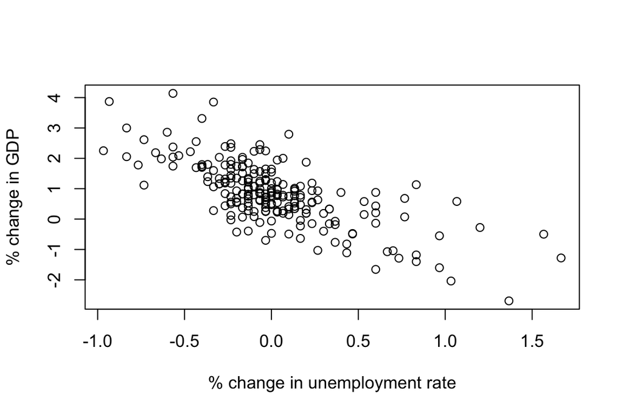

```r
okun.df=read.table("okun.txt", header=T)
plot(GDP~Unemp,xlab="% change in unemployment rate", ylab="% change in GDP",data=okun.df)
```

The relationship between the quarterly % change in unemplyement (explanatory variable) and the quarterly % change in GDP (response variable) appears to be a negative linear relationship. The variation appears to be constant.

## Model fitting

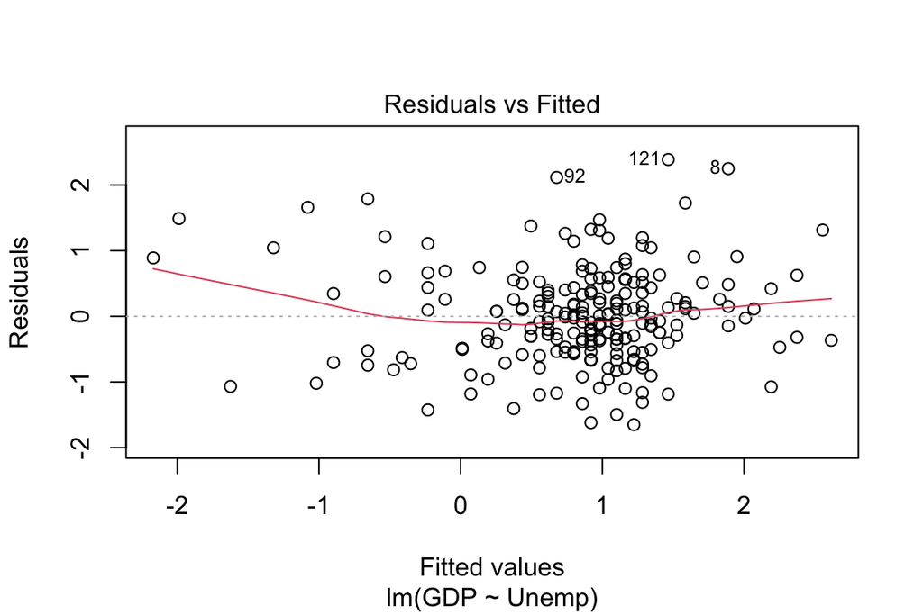

```r
okun.fit=lm(GDP~Unemp,data=okun.df)
plot(okun.fit,which=1)
```

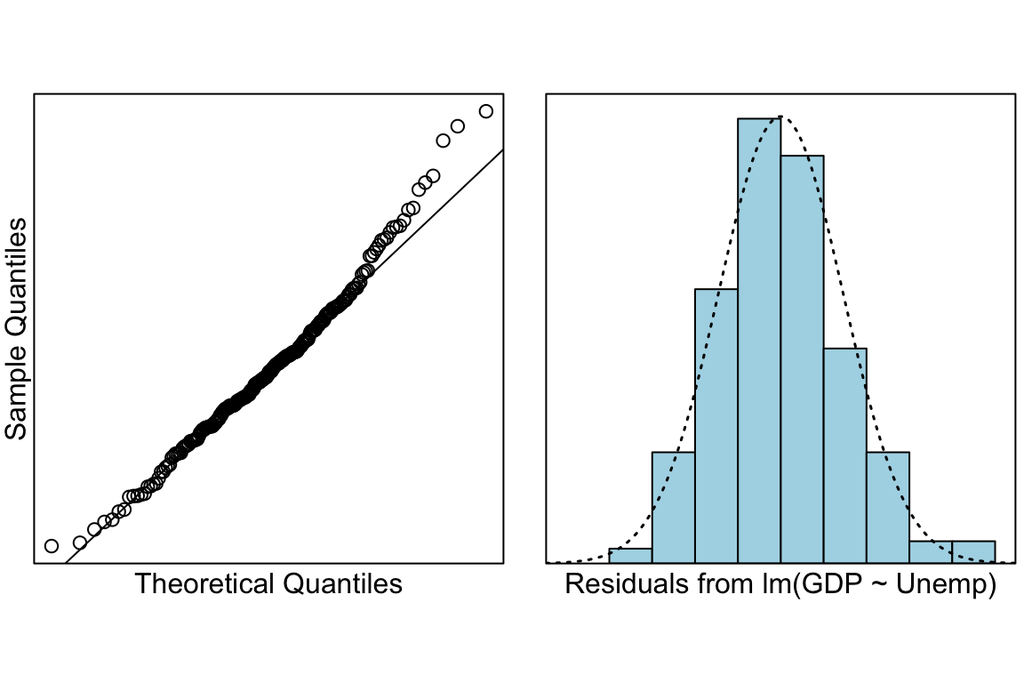

```r
normcheck(okun.fit)
```

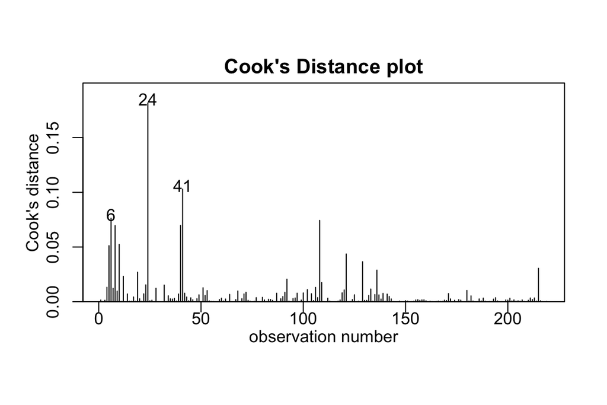

```r
cooks20x(okun.fit)
```

```r
summary(okun.fit)
```

```
##
## Call:
## lm(formula = GDP ~ Unemp, data = okun.df)
##
## Residuals:
##      Min       1Q   Median       3Q      Max
## -1.64968 -0.47865 -0.03645  0.42858  2.38799
##
## Coefficients:
##             Estimate Std. Error t value Pr(>|t|)
## (Intercept)  0.85898    0.04906   17.51   <2e-16 ***
## Unemp       -1.81749    0.12278  -14.80   <2e-16 ***
## ---
## Signif. codes:  0 '***' 0.001 '**' 0.01 '*' 0.05 '.' 0.1 ' ' 1
##
## Residual standard error: 0.7258 on 217 degrees of freedom
## Multiple R-squared:  0.5024, Adjusted R-squared:  0.5001
## F-statistic: 219.1 on 1 and 217 DF,  p-value: < 2.2e-16
```

```r
confint(okun.fit)
```

```
##                  2.5 %    97.5 %
## (Intercept)  0.7622829  0.955676
## Unemp       -2.0594876 -1.575490
```

## Data with model superimposed

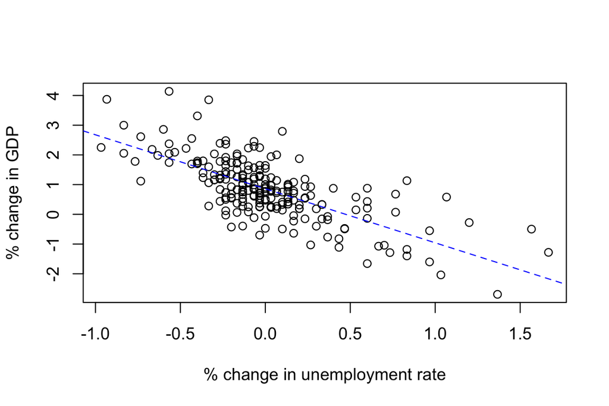

```r
plot(GDP~Unemp,xlab="% change in unemployment rate", ylab="% change in GDP",data=okun.df)
abline(okun.fit, lty = 2, col = "blue")
```

## Prediction for % change in GDP given the % change in unemployment for the final quarter of 2015

```r
predict(okun.fit, newdata = data.frame(Unemp=100 * ((5-5.1) / 5.1)), interval = "prediction")
```

```
##        fit     lwr      upr
## 1 4.422683 2.91165 5.933717
```

Given the % change in unemployment for the final quarter of 2015 (-1.96%), the 95% prediction interval for quarterly change in GDP % was between 2.91% and 5.93%. This interval does not contatin the actual % change in GDP, which was 2%.

A -1.96% is an extremely high change in quarterly unemplyement rate, in our data set there were fewer data points at the negative extrema of % change in unemployment, with the largest decrease in employment being -0.967%. Therefore our model may not be a good predictor when using an extreme % change in unemployment rate. The linear model explained 50.24% of the variability, further reducing the precision of the predicted % change in GDP.

## Method and Assumption Checks

The data follows a linear relationship, so we have fitted a simple linear regression model. There was some concerns with a hint of curvature in the residuals, but this was mostly at the extremes where there were quite sparse data so likely to have been the influenced by just a few points. (Fitting a curve is unlikely to be helpful for this data - any small gain in explanatory power will be heavily offset by the complication in the model.) Note - we are treating these observation as independent which is not correct as this is historical data which is related by time. (Any problems with time dependence can actually be checked for - see Time Series later in the course.) All other assumptions seem valid.

Our model is: $GDP_i =\beta_0 +\beta_1\times Unemp_i +\epsilon_i$ where $\epsilon_i \sim iid ~ N(0,\sigma^2)$

Our model only explains about 50% of the variation in the data (so any predictions won’t be very precise).

## Executive Summary

We were interested in finding the relationship between the quarterly change in GDP (%) and the quarterly change in unemployment rate (%) from a data set from USA. Furthermore, we wanted to see if this relationship conformed with Okun’s Law, i.e. for every 1% decrease in unemployment rate there should be a corresponding 2% increase in GDP.

There was a clear linear relationship between % change in unemployment and % change in GDP (P-value ≈ 0). We estimate that for a for each percentage point increase in quarterly unemployment rate, the quarterly GDP would decrease by -1.58% to -2.06% on average. This 95% confidence interval contains the the value -2% which conforms to okun’s law, i.e a 1% point increase in unemployment rate corresponds to a 2% decrease in GDP, or alternatively, a 1% point decrease in unemployment rate corresponds to a 2% increase in GDP.